# Ayudantía N°2

Juan Miño.

# Cross - Sectional Data

Supongamos que tenemos un conjunto de datos que contiene información sobre los ingresos y algunas características demográficas de individuos en una población.

El objetivo es realizar un análisis exploratorio de estos datos de corte transversal para entender la distribución de los ingresos y cómo están relacionados con las características demográficas.

```r
# Cargar paquetes necesarios
library(ggplot2)
library(dplyr)

# Generar un conjunto de datos de ejemplo
set.seed(123)
num_persons <- 100
data <- data.frame(
  edad = sample(18:65, num_persons, replace = TRUE),
  genero = sample(c("Masculino", "Femenino"), num_persons, replace = TRUE),
  educacion = sample(c("Primaria", "Secundaria", "Universidad"), num_persons, replace = TRUE),
  ingresos = rnorm(num_persons, mean = 40000, sd = 15000)
)

# Análisis exploratorio
summary(data)
```

```
##       edad          genero           educacion            ingresos
##  Min.   :20.00   Length:100         Length:100         Min.   :13652
##  1st Qu.:31.00   Class :character   Class :character   1st Qu.:30632
##  Median :42.50   Mode  :character   Mode  :character   Median :37658
##  Mean   :41.72                                         Mean   :40068
##  3rd Qu.:51.00                                         3rd Qu.:49318
##  Max.   :65.00                                         Max.   :74396
```

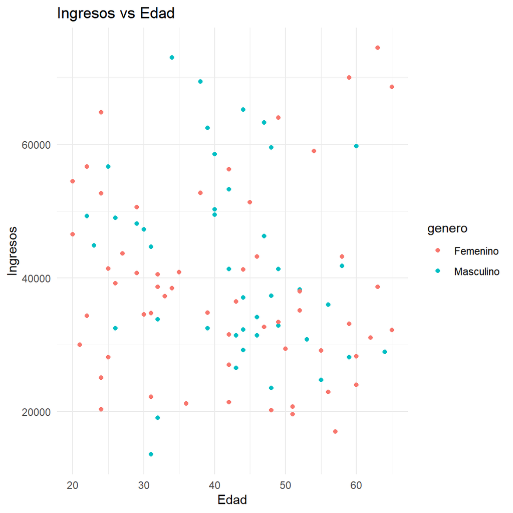

```r
# Gráfico de dispersión de ingresos vs edad
ggplot(data, aes(x = edad, y = ingresos, color = genero)) +
  geom_point() +
  labs(title = "Ingresos vs Edad",
       x = "Edad",
       y = "Ingresos") +
  theme_minimal()
```

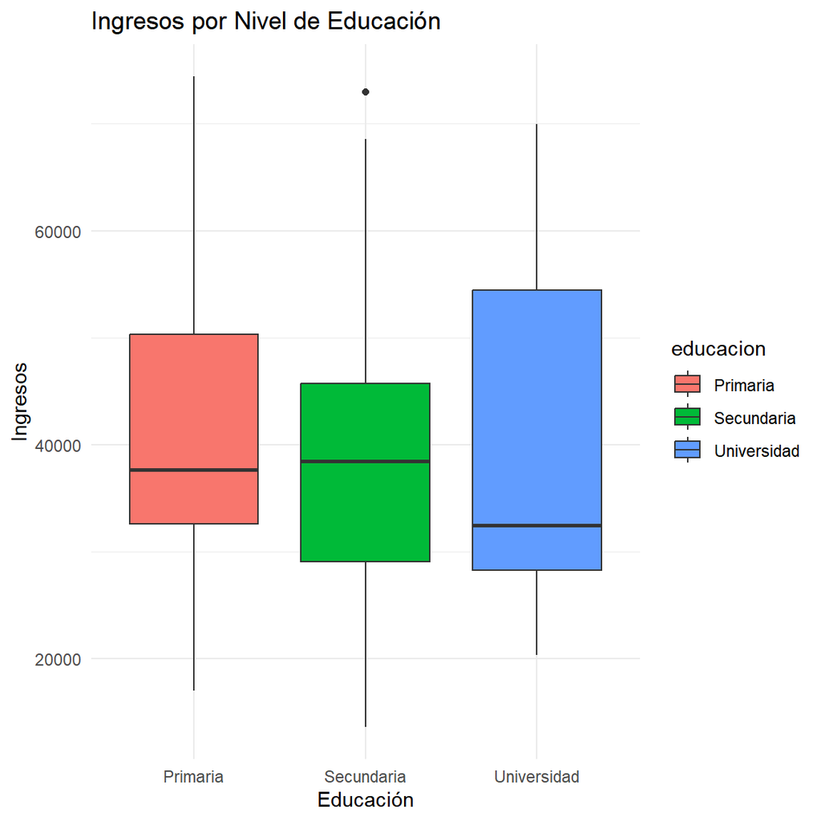

```r
# Gráfico de cajas de ingresos por nivel de educación
ggplot(data, aes(x = educacion, y = ingresos, fill = educacion)) +
  geom_boxplot() +
  labs(title = "Ingresos por Nivel de Educación",
       x = "Educación",
       y = "Ingresos") +
  theme_minimal()
```

Un scatter plot es una representación gráfica que utiliza puntos individuales para mostrar los valores de dos variables diferentes. El gráfico de dispersión muestra la relación entre la edad de los individuos y sus ingresos, y utiliza diferentes colores para representar los géneros diferentes (*masculino* y *femenino*).

# Correlación

Supongamos que tienes un conjunto de datos que contiene información sobre el nivel de ingresos y el gasto en entretenimiento mensual de una muestra de individuos. El objetivo de este ejercicio es calcular y visualizar la correlación entre estas dos variables.

```r
# Cargar paquetes necesarios
library(ggplot2)

# Generar un conjunto de datos de ejemplo
set.seed(123)
num_persons <- 50
data <- data.frame(
  ingresos = rnorm(num_persons, mean = 5000, sd = 1500),
  gasto_entretenimiento = rnorm(num_persons, mean = 200, sd = 50)
)

# Calcular la matriz de correlación
correlation_matrix <- cor(data)

# Visualizar la matriz de correlación
print(correlation_matrix)
```

```
##                          ingresos gasto_entretenimiento
## ingresos               1.00000000           -0.03586983
## gasto_entretenimiento -0.03586983            1.00000000
```

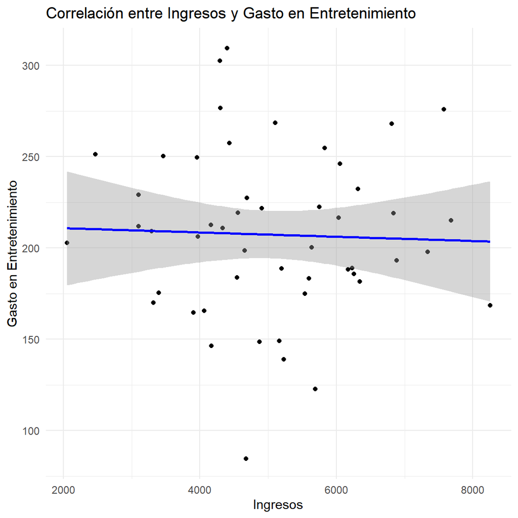

```r
# Gráfico de dispersión con línea de regresión
ggplot(data, aes(x = ingresos, y = gasto_entretenimiento)) +
  geom_point() +
  geom_smooth(method = "lm", color = "blue") +
  labs(title = "Correlación entre Ingresos y Gasto en Entretenimiento",
       x = "Ingresos",
       y = "Gasto en Entretenimiento") +
  theme_minimal()
```

# Causalidad

Supongamos que tenemos datos de una investigación que involucra el efecto de la cantidad de publicidad en el número de ventas de un producto. El objetivo es realizar un análisis de regresión para explorar la relación causal entre la variable independiente (*publicidad*) y la variable dependiente (*ventas*).

```r
# Cargar paquetes necesarios
library(ggplot2)

# Generar un conjunto de datos de ejemplo
set.seed(123)
num_observations <- 100
data <- data.frame(
  publicidad = rnorm(num_observations, mean = 50, sd = 15),
  ventas = 100 + 2 * rnorm(num_observations, mean = 0, sd = 20)  # Corregir esta línea
)

# Ajustar un modelo de regresión lineal
model <- lm(ventas ~ publicidad, data = data)

# Resumen del modelo
summary(model)
```

```
##
## Call:
## lm(formula = ventas ~ publicidad, data = data)
##
## Residuals:
##    Min     1Q Median     3Q    Max
## -76.29 -27.34  -3.50  23.23 131.62
##
## Coefficients:
##             Estimate Std. Error t value Pr(>|t|)
## (Intercept) 102.8841    15.1432   6.794 8.52e-10 ***
## publicidad   -0.1399     0.2850  -0.491    0.625
## ---
## Signif. codes:  0 '***' 0.001 '**' 0.01 '*' 0.05 '.' 0.1 ' ' 1
##
## Residual standard error: 38.83 on 98 degrees of freedom
## Multiple R-squared:  0.002453,   Adjusted R-squared:  -0.007726
## F-statistic: 0.241 on 1 and 98 DF,  p-value: 0.6246
```

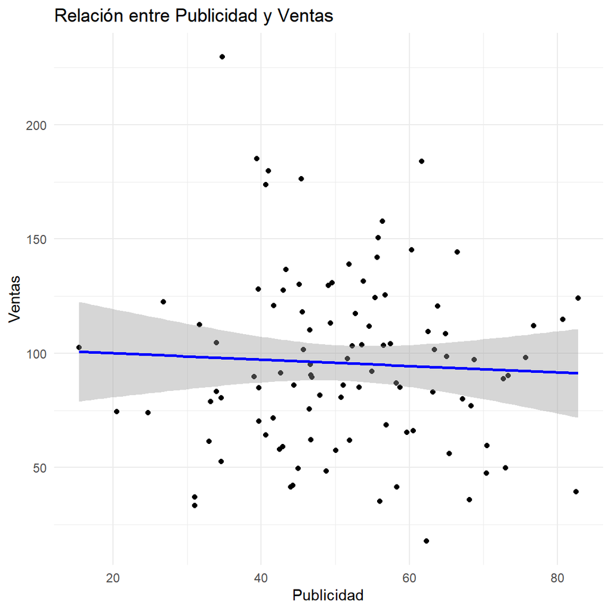

```r
# Gráfico de dispersión con línea de regresión
ggplot(data, aes(x = publicidad, y = ventas)) +
  geom_point() +
  geom_smooth(method = "lm", color = "blue") +
  labs(title = "Relación entre Publicidad y Ventas",
       x = "Publicidad",
       y = "Ventas") +
  theme_minimal()
```

# Como intepretar *summary*

- Valor t (t value): El valor t mide cuántas desviaciones estándar está el coeficiente estimado del valor nulo (hipótesis de que el coeficiente es igual a cero). Cuanto mayor sea el valor t, mayor es la evidencia de que el coeficiente es diferente de cero. Si el valor t es grande en relación con su desviación estándar (generalmente mayor a 2 en valor absoluto), es indicativo de que el coeficiente es significativamente diferente de cero.

$t = \frac{Estimate}{Std.Error}$

- *p-value* (Pr(>|t|)): El valor p es la probabilidad de observar un valor t tan extremo como el observado, asumiendo que la hipótesis nula es verdadera. En otras palabras, es la probabilidad de que el coeficiente sea igual a cero, dada la muestra de datos. Un valor p bajo (generalmente menor a 0.05 o 0.01) sugiere que es poco probable que el coeficiente sea cero y se considera una indicación de que el coeficiente es estadísticamente significativo.
- El coeficiente estimado del intercepto (o constante) es el valor esperado de la variable dependiente cuando todas las variables independientes son iguales a cero.
- El “Estimate” proporciona información sobre la dirección (positiva o negativa) y la magnitud del cambio en la variable dependiente asociado con un cambio unitario en la variable independiente correspondiente.
- El error estándar te proporciona una medida de cuánto confianza tienes en la precisión de la estimación del coeficiente. Coeficientes con errores estándar más pequeños son más precisos y, por lo tanto, más fiables en términos de su interpretación.

Los códigos de significancia y los valores p son dos formas diferentes de comunicar la significancia estadística de los coeficientes en un modelo de regresión. Los códigos de significancia son representaciones visuales que indican la significancia estadística de los coeficientes. Los códigos son una forma rápida de evaluar la importancia relativa de los coeficientes.

# Enfoque de resultados potenciales

El enfoque de resultados potenciales es una herramienta utilizada en el campo de la causalidad para entender y evaluar el impacto causal de un tratamiento, intervención o variable en un grupo de estudio.

Supongamos que estamos investigando si un programa de tutorías tiene un efecto positivo en el rendimiento académico de los estudiantes. Queremos utilizar el enfoque de resultados potenciales para evaluar el impacto causal del programa de tutorías en las calificaciones finales de los estudiantes.

```r
# Cargamos las bibliotecas necesarias
library(dplyr)
library(ggplot2)

# Creamos un conjunto de datos ficticio
set.seed(123)
datos_potenciales <- data.frame(
  estudiante_id = 1:100,
  tratamiento = sample(c(0, 1), 100, replace = TRUE), # 0: Sin tutoría, 1: Con tutoría
  calificacion_inicial = rnorm(100, mean = 70, sd = 5)
)
```

Vamos a acceder a “calificacion_final” en el conjunto de datos “datos_potenciales”. Estamos creando una nueva columna en datos_potenciales donde almacenaremos las calificaciones finales simuladas.

- *with* función permite trabajar con las columnas del conjunto de datos datos_potenciales.
- $5 * tratamiento$ simboliza el efecto del tratamiento. Si tratamiento es 1, entonces habrá un incremento de 5 en la calificación final debido al tratamiento. Si tratamiento es 0, no habrá ningún cambio.
- *rnorm(100, mean = 0, sd = 3)*. Esto genera 100 números aleatorios que siguen una distribución normal con una media (mean) de 0 y una desviación estándar (sd) de 3. Estos números aleatorios representan el ruido o la variabilidad en las calificaciones finales.

En resumen, generaremos un proceso ficticio utilizado para ilustrar cómo se podría simular el efecto causal en un conjunto de datos.

```r
# Simulamos el efecto del tratamiento en las calificaciones
datos_potenciales$calificacion_final <- with(datos_potenciales, calificacion_inicial + 5 * tratamiento + rnorm(100, mean = 0, sd = 3))

# Agrupar los datos por tratamiento
datos_potenciales_grouped <- group_by(datos_potenciales, tratamiento)

# Calcular la media de calificacion_final para cada grupo
efecto_causal <- summarize(datos_potenciales_grouped, calificacion_media = mean(calificacion_final))

print(efecto_causal)
```

```
## # A tibble: 2 x 2
##   tratamiento calificacion_media
##         <dbl>              <dbl>
## 1           0               70.0
## 2           1               74.4
```